# ANALISIS DATA MENGENAI PERUSAHAAN TEKNOLOGI

Dibuat untuk memenuhi tugas mata kuliah Pengenalan Komputasi KU1102 Dosen pengampu: Mohammad Mi'radj Isnaini, S.T., M.T., Ph.D.

## Anggota Kelompok

### Kelompok 13

| NIM | Nama |
| --- | --- |
| 16722047 | Jessica Budiman |
| 16722052 | Delon Khaerun Alief |
| 16722117 | Yuba Felda Tustika |
| 16722167 | Selpia Anggraeni Permatasari |
| 16722292 | Maulida Rahma Britania |

[figure not shown]

# FAKULTAS TEKNOLOGI INDUSTRI

# INSTITUT TEKNOLOGI BANDUNG

# 2022

## Tema: Perusahaan Teknologi

### Deskripsi Data

1. Sumber Dana Perusahaan Teknologi (sumber: [kaggle](https://www.kaggle.com/datasets/shivamb/tech-company-fundings-2020-onwards))

   > Format: CSV  
   > Ukuran: 305 KB  
   > Dimensi: 3575 baris × 7 kolom Pada Tugas Besar II, dianalisis dua buah dataset. Dataset pertama berjudul Tech Fundings, yaitu dataset mengenai informasi terkini tentang pendanaan perusahaan teknologi di seluruh dunia dengan. Dataset ini berisi informasi berisi 3500+ informasi pendanaan perusahaan sejak Januari 2020 hingga September 2021. Dataset diunduh dari situs www.kaggle.com pada 21 November 2022. Dimensi dari dataset terdiri dari 3575 baris dan 7 kolom, yaitu kolom Company, Website, Region, Vertical, Funding Amount (USD). Funding Stage, dan Funding Date. Dari total data yang disajikan terdapat 64 data kosong pada kolom Funding Stage dan Sembilan data kosong pada kolom Funding Amount (USD). Format data Format dari data ini adalah CSV (Comma Separated Values), ini artinya daftar data yang disajikan dipisahkan oleh tanda koma. File CSV ini dirancang untuk menjadi cara mudah mengekspor data dan mengimpornya ke program lain. Data ini dapat dengan mudah dibaca oleh editor teks seperti Microsoft Excel. Ukuran file data yang digunakan ini adalah sebesar 305 KB.
2. Penggabungan dan Akuisisi Perusahaan Teknologi (sumber: [kaggle](https://www.kaggle.com/datasets/shivamb/company-acquisitions-7-top-companies))

   > Format: CSV  
   > Ukuran: 102 KB  
   > Dimensi: 1455 baris × 9 kolom

   Dataset kedua yang digunakan pada tugas besar II adalah dataset mengenai penggabungan dan pemindahan kepemilikan suatu perusahaan atau aset dari sebuah perusahaan teknologi. Pengumpulan dataset ini dilakukan oleh Shivam Bansal dengan bantuan dari sumber-sumber seperti TechCrunch, Wikipedia, dan CrunchBase. Dataset ini berisikan daftar penggabungan perusahaan yang dilakukan oleh perusahaan-perusahaan besar seperti Microsoft, Google, IBM, Hp, Apple, Amazon, Facebook, Twitter, eBay, Adobe, Citrix, Redhat, Blackberry, dan Disney. Dataset ini memuat bulan dan tahun terjadinya akuisisi, nama perusahaan yang diakuisisi, biaya akuisisi, jenis bisnis yang dijalankan oleh perusahaan yang diakuisisi, dan negara tempat akuisisi dilaksanakan. Dataset Merger and Acquisitions by Tech Companies ini diambil pada 21 November 2022. Dimensi dari dataset terdiri dari 1.455 baris dan 10 kolom, yaitu kolom id atau nomor data, parent company atau perusahaan yang mengakuisisi, acquisition year, acquisition month, acquired company, business, country, acquisition price, category, derived products. Dari total semua data yang disajikan, terdapat 28 data kosong pada acquisition year, 58 data kosong pada acquisition month, 274 data kosong pada business, 1114 data kosong pada country, 945 data kosong pada acquisition price, 1440 data kosong pada category, dan 1052 data kosong pada derived products. Ukuran file data yang digunakan ini adalah sebesar 102 KB.

#### Data yang akan dianalisis dan divisualisasikan

# PENDAHULUAN

## Import dan membaca data

```python
#Import dan membaca dataset dengan format csv
import pandas as pd
import matplotlib.pyplot as plt
import numpy as np

data_funding = pd.read_csv('https://raw.githubusercontent.com/elonsquidion/tubes-analisis-data/main/tech_fundings.csv', index_col=0)
data_merger = pd.read_csv('https://raw.githubusercontent.com/elonsquidion/tubes-analisis-data/main/acquisitions_update_2021.csv', index_col=0)
```

```python
#Pencarian dimensi data
print("Dimensi dari dataset Tech Fundings adalah ", data_funding.shape)
print("Dimensi dari dataset Merger and Acquisitions by Tech Companies adalah ", data_merger.shape)
```

```
Dimensi dari dataset Tech Fundings adalah  (3575, 7)
Dimensi dari dataset Merger and Acquisitions by Tech Companies adalah  (1455, 9)
```

## Karakteristik Data

### Dataset 1, Sumber Dana Perusahaan Teknologi

#### Penjelasan atribut/kolom, makna, jenis

- Index: Indeks (Numerikal)
- Company: Nama perusahaan (categorical-nominal)
- Website: situs perusahaan (categorical-nominal)
- Region: Lokasi Headquarter (manajemen eksekutif) perusahaan (company HQ) (categorical-nominal)
- Vertical: Bidang perusahaan (categorical-nominal)
- Funding amount: Total pembiayaan perusahaan (quantitative-discrete)
- Funding stage: Tingkatan pembiayaan perusahaan (categorical-nominal)
- Month: Bulan Pembiayaan perusahaan
- Year: Tahun Pembiayaan perusahaan

#### Penjelasan atribut kategorikal

- Company: Atribut company berisi nama-nama dari perusahaan
- Website: Atribut website berisi nama situs perusahaan
- Region: Atribut region berisi nama lokasi headquarter perusahaan
- Vertical: Atribut vertical berisi bidang perusahaan
- Funding Stage: Atribut funding stage terdiri dari beberapa kategori, yaitu pre-seed, seed, series A, series B, series C, series D, series E, series F, series G, series H, unknown, private equity, angel, debt financing, ICO, crowdfunding, initial coin offering, undisclosed, grant, funding, dan growth

#### Range nilai data pada atribut kuantitatif

- Funding Amount: Atribut funding amount berisi nilai pembiayaan perusahaan dalam range USD 16600000000 s.d. USD 40000
- Funding Date: atribut funding date berisi tanggal pembiayaan perusahaan dari bulan Januari tahun 2020 sampai bulan September 2021

### Dataset 2, Penggabungan dan Akuisisi Perusahaan Teknologi

#### Penjelasan atribut/kolom, makna, jenis

- Parent company: nama induk perusahaan (categorical-nominal)
- Acquisition Year: tahun bergabungnya kedua perusahaan (quantitative-continuous)
- Acquisition month: bulan bergabungnya kedua perusahaan (categorical-ordinal)
- Acquired company: nama perusahaan akuisisi (categorical-nominal)
- Business: jenis jasa/produk yang ditawarkan (categorical-nominal)
- Country: negara asal perusahaan (categorical-nominal)
- Acquisition price: total biaya pengeluaran untuk penggabungan perusahaan (quantitative-discrete)
- Category: kategori dari perusahaan (categorical-nominal)
- Derived products: produk turunan dari penggabungan kedua perusahaan (categorical-nominal)

#### Penjelasan atribut kategorikal

- Parent company: nama-nama dari induk perusahaan
- Acquisition month: Januari, Februari, Maret, April, Mei, Juni, July, Agustus, September, Oktober, November, Desember
- Acquired company: nama-nama dari perusahaan akuisisi
- Business: jenis jasa/produk yang ditawarkan
- Country: negara asal perusahaan-perusahaan
- Category: kategori dari perusahaan
- Derived products: hasil produk turunan dari penggabungan kedua perusahaan

#### Persentase data yang kosong

# Data Cleansing

### Mengecek tipe data tiap-tiap kolom yang ada pada dataset yang dianggap oleh program

Dataset 1

```python
data_funding.info()
```

```
<class 'pandas.core.frame.DataFrame'>
Int64Index: 3575 entries, 1 to 3575
Data columns (total 7 columns):
 #   Column                Non-Null Count  Dtype
---  ------                --------------  -----
 0   Company               3575 non-null   object
 1   Website               3575 non-null   object
 2   Region                3563 non-null   object
 3   Vertical              3575 non-null   object
 4   Funding Amount (USD)  3575 non-null   object
 5   Funding Stage         3575 non-null   object
 6   Funding Date          3575 non-null   object
dtypes: object(7)
memory usage: 223.4+ KB
```

Dataset 2

```python
data_merger.info()
```

```
<class 'pandas.core.frame.DataFrame'>
Int64Index: 1455 entries, 1 to 1455
Data columns (total 9 columns):
 #   Column             Non-Null Count  Dtype
---  ------             --------------  -----
 0   Parent Company     1455 non-null   object
 1   Acquisition Year   1455 non-null   object
 2   Acquisition Month  1455 non-null   object
 3   Acquired Company   1455 non-null   object
 4   Business           1455 non-null   object
 5   Country            1455 non-null   object
 6   Acquisition Price  1455 non-null   object
 7   Category           1455 non-null   object
 8   Derived Products   1455 non-null   object
dtypes: object(9)
memory usage: 113.7+ KB
```

## Dataset 1

Berdasarkan data yang akan dianalisis dan divisualisasikan, dilakukan data cleansing dengan cara menghapus baris yang mengandung data kosong pada kolom: *Funding Amount (USD)*. Ini dilakukan untuk menghilangkan data-data yang tidak diperlukan dalam menganalisis data.

Pada kolom *Funding Stage* terdapat nilai "Unknown" yang tidak perlu dihapus. Hal itu disebabkan karena dataset ini berfokus pada kolom *Funding Amount (USD)*. Penghapusan baris pada data yang memiliki nilai "Unknown" pada kolom *Funding Stage* hanya akan mengurangi data yang dimiliki.

```python
data_funding.drop(data_funding.loc[data_funding['Funding Amount (USD)'] == "Unknown"].index, inplace=True)
```

Setelah data cleansing dilakukan, jumlah baris berkurang dari 3575 baris menjadi 3566 baris.

Data pada kolom Funding Amount (USD) bertipe string. Agar data dapat diplot dan divisualisasikan, data pada kolom Funding Amount (USD) perlu diubah terlebih dahulu menjadi bentuk integer

```python
data_funding = data_funding.astype({"Funding Amount (USD)": int})
```

Berikutnya, kita akan mengubah nilai pada kolom *Funding Date* menjadi tipe data tanggal dan membagi nilai bulan dan tahun menjadi kolom baru.

```python
#Kolom Funding Date dipecah menjadi dua kolom baru
data_funding['Funding Date'] = pd.to_datetime(data_funding['Funding Date'], format='%b-%y')
data_funding['Month'] = data_funding['Funding Date'].dt.month
data_funding['Year'] = data_funding['Funding Date'].dt.year
data_funding.drop(columns='Funding Date', inplace=True)
data_funding
```

| index | Company | Website | Region | Vertical | Funding Amount (USD) | Funding Stage | Month | Year |
| --- | --- | --- | --- | --- | --- | --- | --- | --- |
| 1 | Internxt | https://internxt.com/ | Spain | Blockchain | 278940 | Seed | 1 | 2020 |
| 2 | Dockflow | https://dockflow.com | Belgium | Logistics | 292244 | Seed | 1 | 2020 |
| 3 | api.video | https://api.video | France | Developer APIs | 300000 | Seed | 1 | 2020 |
| 4 | Buck.ai | https://buck.ai/ | United States | Artificial Intelligence | 300000 | Seed | 1 | 2020 |
| 5 | Prodsight | https://www.prodsight.ai | United Kingdom | Artificial Intelligence | 529013 | Seed | 1 | 2020 |
| ... | ... | ... | ... | ... | ... | ... | ... | ... |
| 3571 | Headout | https://www.headout.com | United States | Travel | 12000000 | Series B | 9 | 2021 |
| 3572 | OLIO | https://olioex.com/ | United Kingdom | Wellness | 43000000 | Series B | 9 | 2021 |
| 3573 | Trees for Life | https://treesforlife.org.uk | United Kingdom | Wellness | 2737468 | Crowdfunding | 9 | 2021 |
| 3574 | Britishvolt | https://britishvolt.com/ | United Kingdom | Wellness | 70000000 | Series B | 9 | 2021 |
| 3575 | Greenly | https://www.greenly.earth/ | France | Wellness | 2953675 | Seed | 9 | 2021 |

3566 rows × 8 columns

Berikutnya akan dicek data pembiayaan yang terbesar

```python
data_funding.sort_values(['Funding Amount (USD)'], ascending=False).head()
```

| index | Company | Website | Region | Vertical | Funding Amount (USD) | Funding Stage | Month | Year |
| --- | --- | --- | --- | --- | --- | --- | --- | --- |
| 3567 | WestConnex | https://www.westconnex.com.au/ | Australia | Transportation | 16600000000 | Private Equity | 9 | 2021 |
| 798 | SpaceX | https://www.spacex.com/ | United States | Aerospace | 1901446920 | Unknown | 8 | 2020 |
| 3049 | Databricks | https://databricks.com | United States | Artificial Intelligence | 1600000000 | Series H | 8 | 2021 |
| 2926 | Articulate | https://www.articulate.com | United States | Education | 1500000000 | Series A | 7 | 2021 |
| 97 | Gojek | https://www.gojek.io/ | Indonesia | Food Delivery | 1200000000 | Series G | 3 | 2020 |

Seperti yang terlihat, besar dana sumber dari perusahaan WestConnex terlampau begitu besar dibanding yang lain, hal ini kemungkinan besar disebabkan data yang salah dengan kemasukan angka 0 yang berlebih sehingga digitnya bertambah. Berikutnya akan diubah data tersebut dengan menghilangkan angka 0 pada digit terakhir. Hal ini pun telah dikonfirmasi menurut [website resmi pemerintahan Australia](https://investment.infrastructure.gov.au/projects/ProjectDetails.aspx?Project_id=048726-12NSW-NP).

```python
data_funding.loc[data_funding['Company'] == 'WestConnex', 'Funding Amount (USD)'] = 1660000000
```

## Dataset 2

```python
data_merger.drop(data_merger.loc[data_merger['Acquisition Year'] == "-"].index, inplace=True)
data_merger['Acquisition Year'] = data_merger['Acquisition Year'].astype(int)
data_merger['Country'] = data_merger['Country'].replace(["-"], ["Others"])
data_merger.drop(data_merger.loc[data_merger['Acquisition Price'] == "-"].index, inplace=True)
data_merger.drop(data_merger.loc[data_merger['Acquisition Price'] == "undisclosed"].index, inplace=True)
data_merger['Acquisition Price'] = data_merger['Acquisition Price'].astype(int)
data_merger.drop(data_merger.loc[data_merger['Business'] == "-"].index, inplace=True)
data_merger.drop(data_merger.loc[data_merger['Acquisition Month'] == "-"].index, inplace=True)

data_merger
```

| ID | Parent Company | Acquisition Year | Acquisition Month | Acquired Company | Business | Country | Acquisition Price | Category | Derived Products |
| --- | --- | --- | --- | --- | --- | --- | --- | --- | --- |
| 6 | Apple | 1997 | Feb | NeXT | Unix-like hardware and software platform | Others | 404000000 | - | - |
| 7 | Apple | 1997 | Sep | Power Computing Corporation | Macintosh clones | Others | 110000000 | - | - |
| 8 | Apple | 1999 | Jan | Xemplar Education | Software | Others | 4926000 | - | - |
| 9 | Apple | 1999 | Nov | Raycer Graphics | Computer graphic chips | Others | 15000000 | - | - |
| 15 | Apple | 2001 | Jul | Spruce Technologies | Graphics software | Others | 14900000 | - | - |
| ... | ... | ... | ... | ... | ... | ... | ... | ... | ... |
| 1373 | Redhat | 2012 | Dec | ManageIQ | Orchestration software | Others | 104000000 | - | - |
| 1375 | Redhat | 2014 | Apr | Inktank Storage | Ceph | Others | 175000000 | - | - |
| 1376 | Redhat | 2014 | Jun | eNovance | OpenStack Integration Services | Others | 95000000 | - | - |
| 1377 | Redhat | 2014 | Sep | FeedHenry | Mobile Application Platform | Others | 82000000 | - | - |
| 1382 | Redhat | 2018 | Jan | CoreOS | Management of containerized application:Contai... | Others | 250000000 | - | - |

285 rows × 9 columns

# Statistik

## Statistik Dataset 1

### Sampel Data

```python
data_funding.head(10)
```

| index | Company | Website | Region | Vertical | Funding Amount (USD) | Funding Stage | Month | Year |
| --- | --- | --- | --- | --- | --- | --- | --- | --- |
| 1 | Internxt | https://internxt.com/ | Spain | Blockchain | 278940 | Seed | 1 | 2020 |
| 2 | Dockflow | https://dockflow.com | Belgium | Logistics | 292244 | Seed | 1 | 2020 |
| 3 | api.video | https://api.video | France | Developer APIs | 300000 | Seed | 1 | 2020 |
| 4 | Buck.ai | https://buck.ai/ | United States | Artificial Intelligence | 300000 | Seed | 1 | 2020 |
| 5 | Prodsight | https://www.prodsight.ai | United Kingdom | Artificial Intelligence | 529013 | Seed | 1 | 2020 |
| 6 | Harvestr | http://harvestr.io/ | France | B2B Software | 650000 | Angel | 1 | 2020 |
| 7 | Seatrec | http://seatrec.com/ | United States | Marine Technology | 970000 | Seed | 1 | 2020 |
| 8 | BeeCanvas | https://beecanvas.com/en | United States | B2B Software | 1000000 | Seed | 1 | 2020 |
| 9 | SmartKarrot | https://www.smartkarrot.com/ | United States | B2B Software | 1000000 | Angel | 1 | 2020 |
| 10 | Prisync | https://prisync.com | Turkey | B2B Software | 1100000 | Seed | 1 | 2020 |

### Statistik pada dataset 1

```python
numericData1 = ["Funding Amount (USD)"]
for i in range(len(numericData1)):
    data = numericData1[i]
    print(str(i+1) + ". " + data)
    print("Rata-rata: " + str(data_funding[data].mean()))
    print("Standar Deviasi: " + str(data_funding[data].std()))
    print("Min: " + str(data_funding[data].min()))
    print("10%: " + str(data_funding[data].quantile(0.10)))
    print("25%: " + str(data_funding[data].quantile(0.25)))
    print("50%: " + str(data_funding[data].quantile(0.50)))
    print("75%: " + str(data_funding[data].quantile(0.75)))
    print("90%: " + str(data_funding[data].quantile(0.90)))
    print("Max: " + str(data_funding[data].max()))
    print("Distribusi Nilai Frekuensi:")
    print(f"\t{str(data_funding[data].min())} - {str((data_funding[data].quantile(0.10)))} = {str(len(data_funding[(data_funding[data] >= data_funding[data].min()) & (data_funding[data] < data_funding[data].quantile(0.10))]))} data")
    print(f"\t{str(data_funding[data].quantile(0.10))} - {str((data_funding[data].quantile(0.25)))} = {str(len(data_funding[(data_funding[data] >= data_funding[data].quantile(0.10)) & (data_funding[data] < data_funding[data].quantile(0.25))]))} data")
    print(f"\t{str(data_funding[data].quantile(0.25))} - {str((data_funding[data].quantile(0.50)))} = {str(len(data_funding[(data_funding[data] >= data_funding[data].quantile(0.25)) & (data_funding[data] < data_funding[data].quantile(0.50))]))} data")
    print(f"\t{str(data_funding[data].quantile(0.50))} - {str((data_funding[data].quantile(0.75)))} = {str(len(data_funding[(data_funding[data] >= data_funding[data].quantile(0.50)) & (data_funding[data] < data_funding[data].quantile(0.75))]))} data")
    print(f"\t{str(data_funding[data].quantile(0.75))} - {str((data_funding[data].quantile(0.90)))} = {str(len(data_funding[(data_funding[data] >= data_funding[data].quantile(0.50)) & (data_funding[data] < data_funding[data].quantile(0.75))]))} data")
    print(f"\t{str(data_funding[data].quantile(0.90))} - {str((data_funding[data].max()))} = {str(len(data_funding[(data_funding[data] >= data_funding[data].quantile(0.90)) & (data_funding[data] < data_funding[data].max())]))} data")
    print()
```

```
1. Funding Amount (USD)
Rata-rata: 53370572.855300054
Standar Deviasi: 113418365.5049143
Min: 40000
10%: 2000000.0
25%: 5000000.0
50%: 15496301.5
75%: 50000000.0
90%: 133000000.0
Max: 1901446920
Distribusi Nilai Frekuensi:
	40000 - 2000000.0 = 355 data
	2000000.0 - 5000000.0 = 520 data
	5000000.0 - 15496301.5 = 908 data
	15496301.5 - 50000000.0 = 810 data
	50000000.0 - 133000000.0 = 810 data
	133000000.0 - 1901446920 = 358 data
```

## Statistik Dataset 2

### Sampel Data

```python
data_merger.head(10)
```

| ID | Parent Company | Acquisition Year | Acquisition Month | Acquired Company | Business | Country | Acquisition Price | Category | Derived Products |
| --- | --- | --- | --- | --- | --- | --- | --- | --- | --- |
| 6 | Apple | 1997 | Feb | NeXT | Unix-like hardware and software platform | Others | 404000000 | - | - |
| 7 | Apple | 1997 | Sep | Power Computing Corporation | Macintosh clones | Others | 110000000 | - | - |
| 8 | Apple | 1999 | Jan | Xemplar Education | Software | Others | 4926000 | - | - |
| 9 | Apple | 1999 | Nov | Raycer Graphics | Computer graphic chips | Others | 15000000 | - | - |
| 15 | Apple | 2001 | Jul | Spruce Technologies | Graphics software | Others | 14900000 | - | - |
| 16 | Apple | 2001 | Dec | PowerSchool | Online info systems services | Others | 66100000 | - | - |
| 17 | Apple | 2002 | Feb | Nothing Real | Special effects software | Others | 15000000 | - | - |
| 18 | Apple | 2002 | Apr | Zayante | FireWire chips and software | Others | 13000000 | - | - |
| 19 | Apple | 2002 | Jun | Silicon Grail Corp-Chalice | Digital effects software | Others | 20000000 | - | - |
| 21 | Apple | 2002 | Jun | Prismo Graphics | Special-effects titling software for film and ... | Others | 20000000 | - | - |

### Statistik pada dataset 2

```python
numericData2 = ["Acquisition Year", "Acquisition Price"]
for i in range(len(numericData2)):
    data = numericData2[i]
    print(str(i+1) + ". " + data)
    print("Rata-rata: " + str(data_merger[data].mean()))
    print("Standar Deviasi: " + str(data_merger[data].std()))
    print("Min: " + str(data_merger[data].min()))
    print("10%: " + str(data_merger[data].quantile(0.10)))
    print("25%: " + str(data_merger[data].quantile(0.25)))
    print("50%: " + str(data_merger[data].quantile(0.50)))
    print("75%: " + str(data_merger[data].quantile(0.75)))
    print("90%: " + str(data_merger[data].quantile(0.90)))
    print("Max: " + str(data_merger[data].max()))
    print("Distribusi Nilai Frekuensi:")
    print(f"\t{str(data_merger[data].min())} - {str((data_merger[data].quantile(0.10)))} = {str(len(data_merger[(data_merger[data] >= data_merger[data].min()) & (data_merger[data] < data_merger[data].quantile(0.10))]))} data")
    print(f"\t{str(data_merger[data].quantile(0.10))} - {str((data_merger[data].quantile(0.25)))} = {str(len(data_merger[(data_merger[data] >= data_merger[data].quantile(0.10)) & (data_merger[data] < data_merger[data].quantile(0.25))]))} data")
    print(f"\t{str(data_merger[data].quantile(0.25))} - {str((data_merger[data].quantile(0.50)))} = {str(len(data_merger[(data_merger[data] >= data_merger[data].quantile(0.25)) & (data_merger[data] < data_merger[data].quantile(0.50))]))} data")
    print(f"\t{str(data_merger[data].quantile(0.50))} - {str((data_merger[data].quantile(0.75)))} = {str(len(data_merger[(data_merger[data] >= data_merger[data].quantile(0.50)) & (data_merger[data] < data_merger[data].quantile(0.75))]))} data")
    print(f"\t{str(data_merger[data].quantile(0.75))} - {str((data_merger[data].quantile(0.90)))} = {str(len(data_merger[(data_merger[data] >= data_merger[data].quantile(0.50)) & (data_merger[data] < data_merger[data].quantile(0.75))]))} data")
    print(f"\t{str(data_merger[data].quantile(0.90))} - {str((data_merger[data].max()))} = {str(len(data_merger[(data_merger[data] >= data_merger[data].quantile(0.90)) & (data_merger[data] < data_merger[data].max())]))} data")
    print()
```

```
1. Acquisition Year
Rata-rata: 2008.5894736842106
Standar Deviasi: 6.391832492277958
Min: 1987
10%: 2000.0
25%: 2004.0
50%: 2010.0
75%: 2013.0
90%: 2016.6
Max: 2021
Distribusi Nilai Frekuensi:
	1987 - 2000.0 = 24 data
	2000.0 - 2004.0 = 44 data
	2004.0 - 2010.0 = 69 data
	2010.0 - 2013.0 = 66 data
	2013.0 - 2016.6 = 66 data
	2016.6 - 2021 = 26 data

2. Acquisition Price
Rata-rata: 1155661596.491228
Standar Deviasi: 4503035484.898652
Min: 450000
10%: 17914800.0
25%: 50000000.0
50%: 151000000.0
75%: 480000000.0
90%: 1459999999.9999995
Max: 50100000000
Distribusi Nilai Frekuensi:
	450000 - 17914800.0 = 29 data
	17914800.0 - 50000000.0 = 41 data
	50000000.0 - 151000000.0 = 72 data
	151000000.0 - 480000000.0 = 71 data
	480000000.0 - 1459999999.9999995 = 71 data
	1459999999.9999995 - 50100000000 = 28 data
```

# Visualisasi

### Distribusi Histogram Besar Dana Sumber Perusahaan

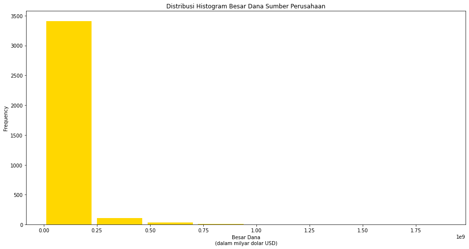

```python
colors = ['gold', 'yellowgreen', 'lightcoral', 'lightskyblue', 'lightpink', 'cyan', 'lime', 'turquoise', 'fuchsia', 'coral']
data_funding['Funding Amount (USD)'].plot(kind='hist', bins=8, figsize=(16,8), color=colors, rwidth=0.9, title="Distribusi Histogram Besar Dana Sumber Perusahaan")
plt.xlabel("Besar Dana\n(dalam milyar dolar USD)")
plt.show()
```

### Perbandingan Tahap Pembiayaan Perusahaan

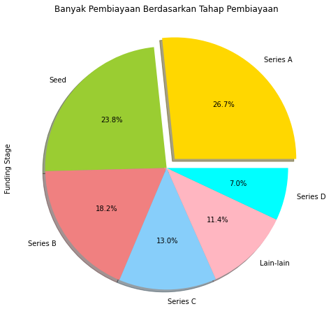

```python
terbesar = data_funding['Funding Stage'].value_counts()[:5]
terbesar = list(terbesar.keys())

def lain(x):
  if x not in terbesar:
    return "Lain-lain"
  else:
    return x

pd.DataFrame(data_funding['Funding Stage'].apply(lambda x: lain(x)))['Funding Stage'].value_counts().plot(kind='pie', title="Banyak Pembiayaan Berdasarkan Tahap Pembiayaan", figsize=(16,8), autopct='%1.1f%%', explode=[0.1,0,0,0,0,0], shadow=True, colors=colors)
plt.show()
```

Dominasi tahap pembiayaan berada pada tahap *Series A* lalu disusul *Seed* yang tidak terpaut begitu jauh.

### Peningkatan Besar Dana Sumber

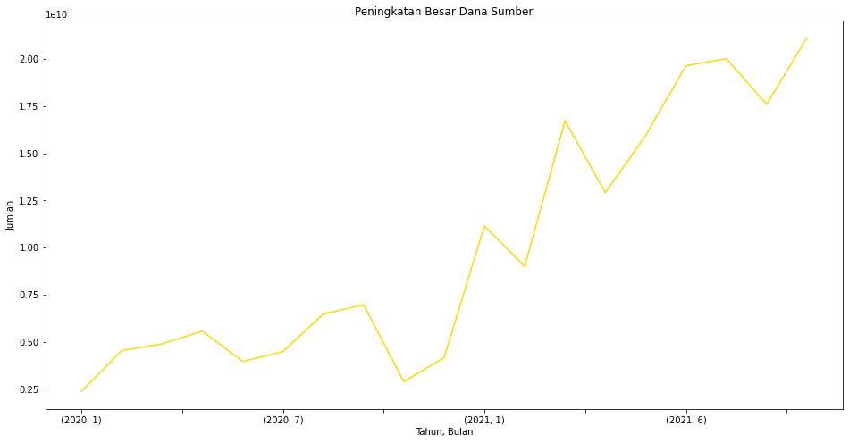

```python
data_funding.groupby(['Year', 'Month']).sum()['Funding Amount (USD)'].plot(kind='line', figsize=(16,8), color='gold', xlabel='Tahun, Bulan', ylabel='Jumlah', title='Peningkatan Besar Dana Sumber')

plt.show()
```

Besar dana sumber perusahaan memiliki tren yang meningkat.

### Peningkatan Besar Dana Sumber untuk Negara USA

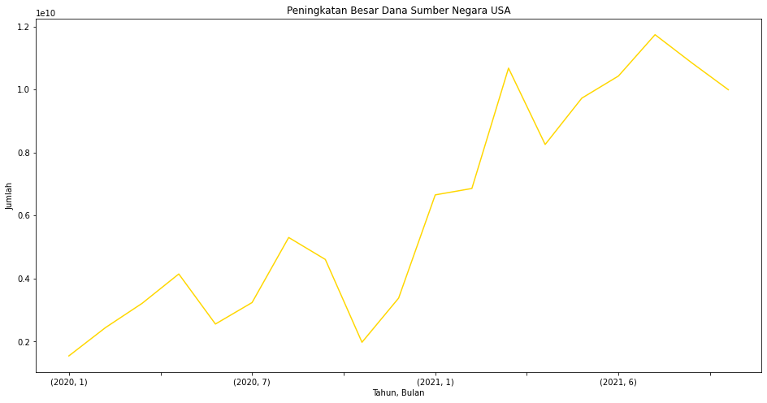

```python
data_funding[data_funding['Region'] == 'United States'].groupby(['Year', 'Month']).sum()['Funding Amount (USD)'].plot(kind='line', figsize=(16,8), color='gold', xlabel='Tahun, Bulan', ylabel='Jumlah', title='Peningkatan Besar Dana Sumber Negara USA')

plt.show()
```

Tren besar dana sumber perusahaan asal USA praktis mirip dengan tren keseluruhan.

### Kategori Perusahaan yang Memiliki Sumber Dana Terbesar

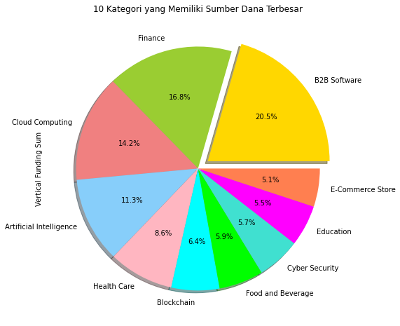

```python
data_funding['Vertical Funding Sum'] = data_funding.groupby('Vertical')['Funding Amount (USD)'].transform('sum')
data_funding[['Vertical', 'Vertical Funding Sum']].drop_duplicates().sort_values(["Vertical Funding Sum"], ascending= False)[:10].plot(kind='pie', y = 'Vertical Funding Sum', legend=False, labels=data_funding[['Vertical', 'Vertical Funding Sum']].drop_duplicates().sort_values(["Vertical Funding Sum"], ascending= False)[:10]['Vertical'],autopct='%1.1f%%', figsize=(16,8), title = "10 Kategori yang Memiliki Sumber Dana Terbesar", explode=[0.1,0,0,0,0,0,0,0,0,0], shadow=True, colors=colors)
plt.show()
```

Sumber dana terbesar dipegang oleh perusahaan dengan jenis berturut-turut B2B Software, Finance, Cloud Computing, AI, dst..

### Sepuluh Perusahaan dengan Sumber Pendanaan Terbesar

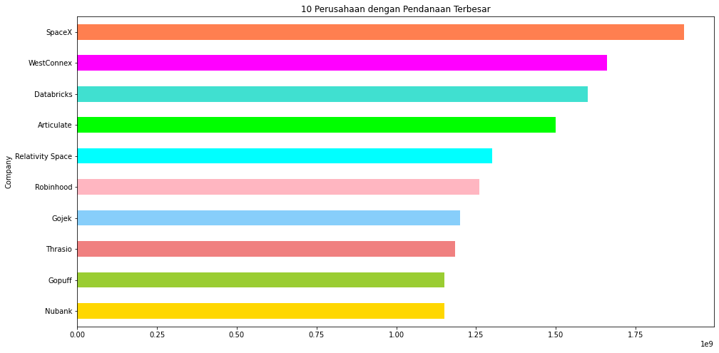

```python
data_funding['Company Funding Sum'] = data_funding.groupby('Company')['Funding Amount (USD)'].transform('sum')
data_funding[['Company', 'Company Funding Sum']].drop_duplicates().sort_values(["Company Funding Sum"], ascending=False)[:10].sort_values(['Company Funding Sum']).plot(kind="barh",x="Company",y="Company Funding Sum", figsize=(16,8), title= "10 Perusahaan dengan Pendanaan Terbesar", color=colors, legend=False)
plt.show()
```

Perusahaan dengan besar dana terbesar adalah berturut-turut SpaceX, WestConnex, Databricks, Articulate, dst..

### Hubungan antara Besar Pendanaan dan Bulan Pendanaan pada 2020

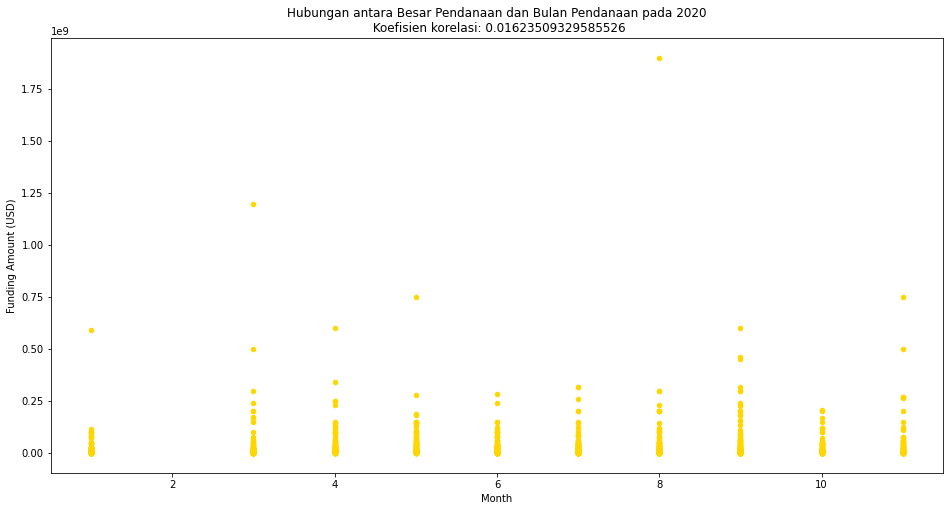

```python
data_funding[data_funding['Year'] == 2020].plot(kind="scatter", x="Month", y="Funding Amount (USD)", figsize=(16,8), color='gold')
koef = str(data_funding[data_funding['Year'] == 2020]['Month'].corr(data_funding['Funding Amount (USD)']))
plt.title("Hubungan antara Besar Pendanaan dan Bulan Pendanaan pada 2020\n Koefisien korelasi: " + koef)

plt.show()
```

Kedua hubungan tersebut tidak berhubungan sama sekali karena memiliki nilai koefisien korelasi yang kecil mendekati 0.

### Hubungan antara Besar Pendanaan dan Bulan Pendanaan pada 2021

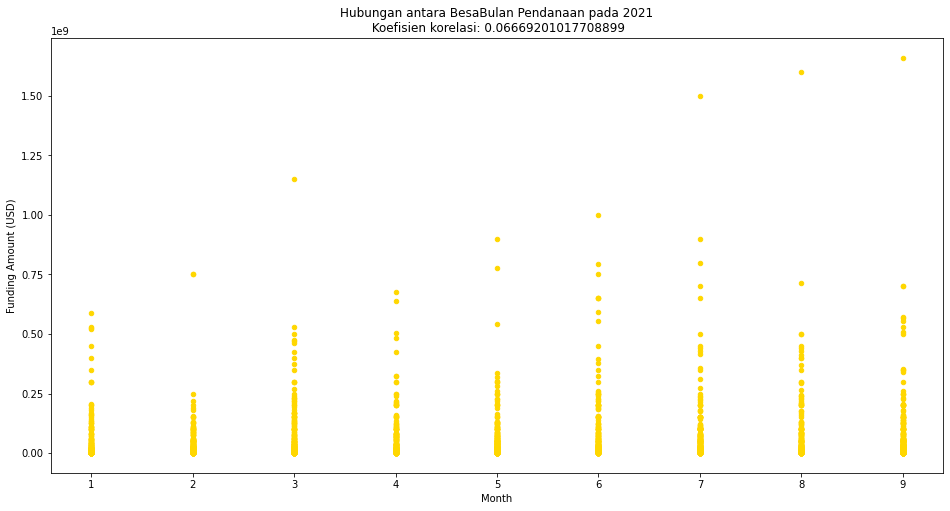

```python
data_funding[data_funding['Year'] == 2021].plot(kind="scatter", x="Month", y="Funding Amount (USD)", figsize=(16,8), color='gold')
koef = str(data_funding[data_funding['Year'] == 2021]['Month'].corr(data_funding['Funding Amount (USD)']))
plt.title("Hubungan antara BesaBulan Pendanaan pada 2021\n Koefisien korelasi: " + koef)

plt.show()
```

Kedua hubungan tersebut tidak berhubungan sama sekali karena memiliki nilai koefisien korelasi yang kecil mendekati 0.

## Dataset 2

### Perbandingan Jumlah Perusahaan yang Dibeli oleh Perusahaan Induk Setiap Tahun

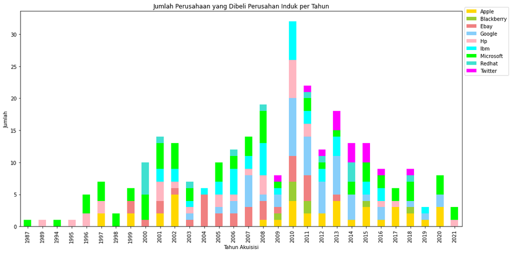

```python
ax = data_merger.groupby(["Acquisition Year", "Parent Company"]).size().unstack().plot(kind="bar", stacked=True, title="Jumlah Perusahaan yang Dibeli Perusahan Induk per Tahun", figsize=(16,8), xlabel="Tahun Akuisisi", ylabel="Jumlah", color=colors)
ax.legend(bbox_to_anchor=(1, 1.03), loc='upper left')

plt.show()
```

Jumlah perusahaan yang dibeli per tahun berdasarkan perusahaan induk cukup beragam dan mencapai puncaknya pada tahun 2010.

### Perbandingan Jumlah Akuisisi Perusahaan Untuk Bisnis Software dengan Bisnis Lainnya

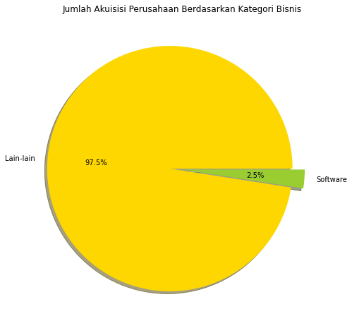

```python
data_merger_pie = data_merger
data_merger_pie['Business'] = np.where(data_merger_pie["Business"]!="Software","Lain-lain", data_merger_pie["Business"])
data_merger_pie["Business"].value_counts().plot(kind="pie", ylabel='', title="Jumlah Akuisisi Perusahaan Berdasarkan Kategori Bisnis", autopct='%1.1f%%', shadow=True, explode=[0.1, 0], colors=colors, figsize=(16,8))

plt.show()
```

Jumlah akuisi perusahaan untuk bisnis Software relatif kecil dibanding yang lainnya.

### Jumlah Akuisisi Perusahaan Setiap Tahun

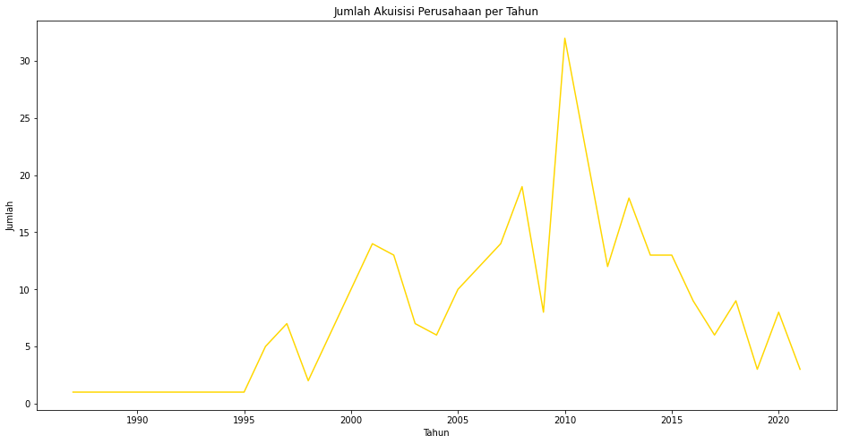

```python
data_merger["Acquisition Year"].value_counts().sort_index().plot(kind="line", title="Jumlah Akuisisi Perusahaan per Tahun", xlabel='Tahun', ylabel="Jumlah", figsize=(16,8), color=colors)
plt.show()
```

Jumlah akuisisi perusahaan tiap tahun memiliki tren yang naik turun dan mencapai titik tertinggi pada tahun 2010.

### Jumlah Akuisisi Perusahaan Dari Tahun ke Tahun Untuk Perusahaan Induk Asal United States

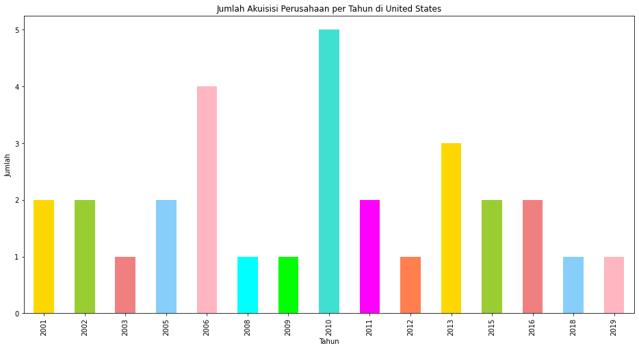

```python
data_us = data_merger.loc[data_merger["Country"]=="United States"]

data_us["Acquisition Year"].value_counts().sort_index().plot(kind="bar", title="Jumlah Akuisisi Perusahaan per Tahun di United States", xlabel='Tahun', ylabel='Jumlah', figsize=(16,8), color=colors)

plt.show()
```

### Urutan Jumlah Akuisisi dari Setiap Perusahaan Induk dari yang Terbanyak

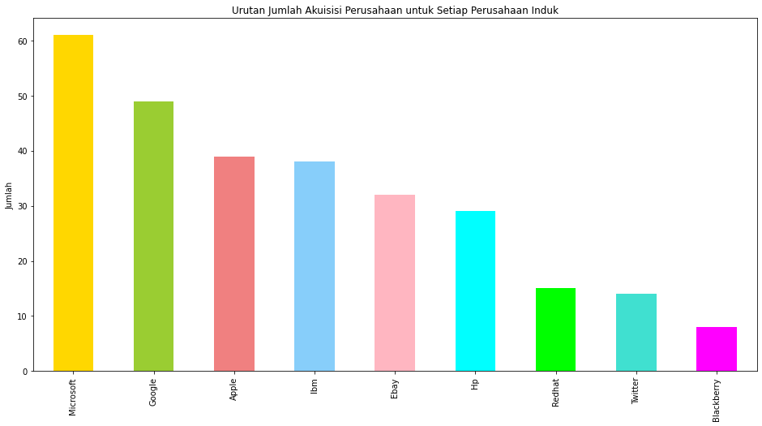

```python
data_merger["Parent Company"].value_counts().plot(kind="bar", title="Urutan Jumlah Akuisisi Perusahaan untuk Setiap Perusahaan Induk", ylabel='Jumlah', color=colors, figsize=(16,8))

plt.show()
```

Perusahaan induk yang paling banyak mengakuisisi berturut-turut adalah Microsoft, Google, Apple, IBM, Ebay, HP, dst..

### Urutan Rata-rata Harga Akuisisi Perusahaan Untuk Setiap Perusahaan Induk

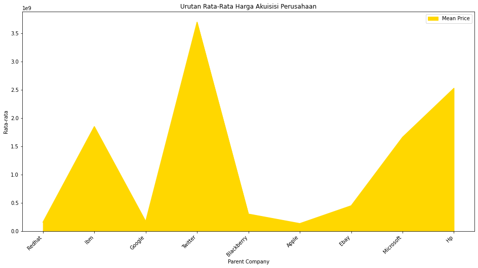

```python
list_company = list(set(data_merger["Parent Company"].tolist()))
data_C = []
for company in list_company:
    mean_price = data_merger["Acquisition Price"][data_merger["Parent Company"] == company].mean()
    data_C.append([company, mean_price])

df3 = pd.DataFrame(data_C, columns = ["Parent Company", "Mean Price"])
df3.plot(kind="area", x = "Parent Company" , y = "Mean Price", title="Urutan Rata-Rata Harga Akuisisi Perusahaan", figsize=(16,8), ylabel='Rata-rata', color=colors)
plt.xticks(rotation=45, ha='right')

plt.show()
```

Perusahaan yang memiliki harga beli rerata tertinggi berturut-turut adalah Twitter, HP, IBM, dst..

### Hubungan Antara Harga Akuisisi Perusahaan dengan Tahun Akuisisi Perusahaan

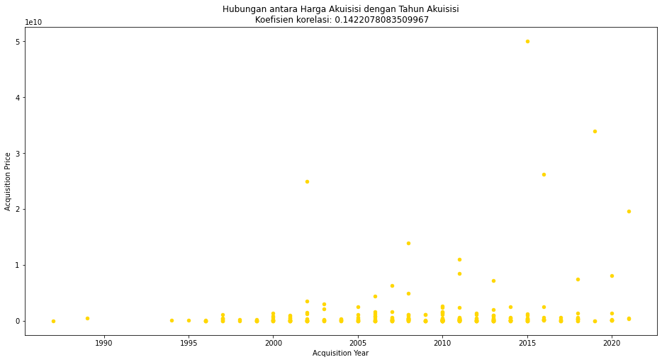

```python
# Hubungan antara harga akuisisi perusahaan dengan tahun akuisisi perusahaan
data_merger.plot(kind="scatter", x="Acquisition Year", y="Acquisition Price", figsize=(16,8), color='gold')
koef = str(data_merger['Acquisition Year'].corr(data_merger['Acquisition Price']))
plt.title("Hubungan antara Harga Akuisisi dengan Tahun Akuisisi\n Koefisien korelasi: " + koef)

plt.show()
```

### Hubungan Antara Harga Akuisisi Perusahaan dengan Bulan Akuisisi Perusahaan

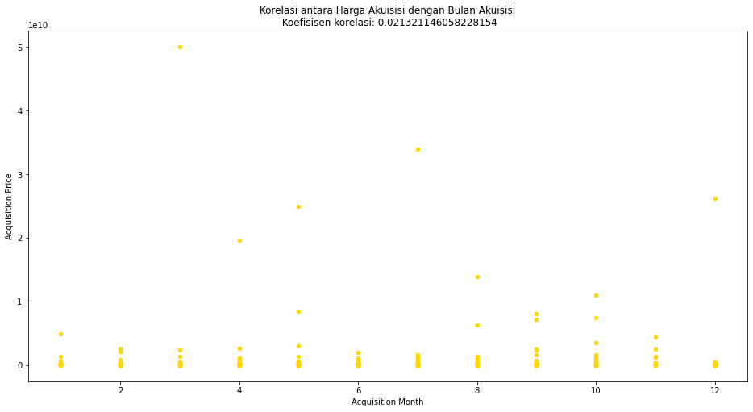

```python
# Hubungan antara harga akuisisi perusahaan dengan bulan akuisisi (scatter plot)

data_merger_scatter = data_merger
data_merger_scatter['Acquisition Month'] = np.where(data_merger_scatter["Acquisition Month"]=="Jan",1, data_merger_scatter["Acquisition Month"])
data_merger_scatter['Acquisition Month'] = np.where(data_merger_scatter["Acquisition Month"]=="Feb",2, data_merger_scatter["Acquisition Month"])
data_merger_scatter['Acquisition Month'] = np.where(data_merger_scatter["Acquisition Month"]=="Mar",3, data_merger_scatter["Acquisition Month"])
data_merger_scatter['Acquisition Month'] = np.where(data_merger_scatter["Acquisition Month"]=="Apr",4, data_merger_scatter["Acquisition Month"])
data_merger_scatter['Acquisition Month'] = np.where(data_merger_scatter["Acquisition Month"]=="May",5, data_merger_scatter["Acquisition Month"])
data_merger_scatter['Acquisition Month'] = np.where(data_merger_scatter["Acquisition Month"]=="Jun",6, data_merger_scatter["Acquisition Month"])
data_merger_scatter['Acquisition Month'] = np.where(data_merger_scatter["Acquisition Month"]=="Jul",7, data_merger_scatter["Acquisition Month"])
data_merger_scatter['Acquisition Month'] = np.where(data_merger_scatter["Acquisition Month"]=="Aug",8, data_merger_scatter["Acquisition Month"])
data_merger_scatter['Acquisition Month'] = np.where(data_merger_scatter["Acquisition Month"]=="Sep",9, data_merger_scatter["Acquisition Month"])
data_merger_scatter['Acquisition Month'] = np.where(data_merger_scatter["Acquisition Month"]=="Oct",10, data_merger_scatter["Acquisition Month"])
data_merger_scatter['Acquisition Month'] = np.where(data_merger_scatter["Acquisition Month"]=="Nov",11, data_merger_scatter["Acquisition Month"])
data_merger_scatter['Acquisition Month'] = np.where(data_merger_scatter["Acquisition Month"]=="Dec",12, data_merger_scatter["Acquisition Month"])

koef = str(data_merger_scatter['Acquisition Month'].astype(int).corr(data_merger_scatter['Acquisition Price']))
data_merger_scatter.plot(kind="scatter", x="Acquisition Month", y="Acquisition Price", color="gold", figsize=(16,8))

plt.title("Korelasi antara Harga Akuisisi dengan Bulan Akuisisi\n Koefisisen korelasi: " + koef)

plt.show()
```

Kedua hubungan tersebut tidak berhubungan sama sekali karena memiliki nilai koefisien korelasi yang kecil mendekati 0.